# viz_i

Part I

2025-09-25

```r
library(tidyverse)
library(ggridges)
```

# Load the weather data

```r
library(p8105.datasets)
data("weather_df")
```

# Scatterplots!!

```r
ggplot(weather_df, aes(x=tmin, y=tmax)) +
  geom_point()
```

[output not shown]

New approach, same plot

```r
weather_df %>%
  ggplot(aes(x=tmin, y=tmax)) +
  geom_point()
```

[output not shown]

Save and edit a plot object.

```r
weather_plot=
  weather_df %>%
  ggplot(aes(x=tmin, y=tmax))

weather_plot + geom_point()
```

[output not shown]

## Advanced scatterplot

Start with the same one and make it fancy!

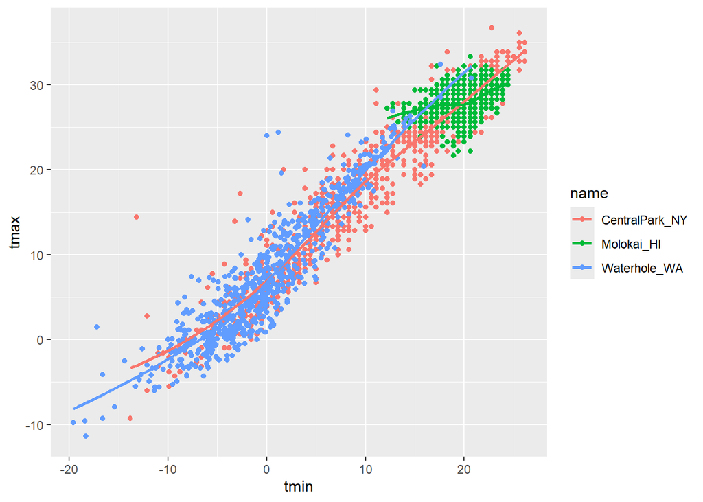

```r
weather_df %>%
  ggplot(aes(x=tmin, y=tmax, color=name)) +
  geom_point()+
  geom_smooth(se=FALSE)
```

（aes 在 ggplot() 中全局映射，color=name 成为全局设置，所有图层（点和拟合线）都按 name 分组着色，会为每个 name 分别绘制一条对应颜色的拟合线）

What about the `aes` placement?

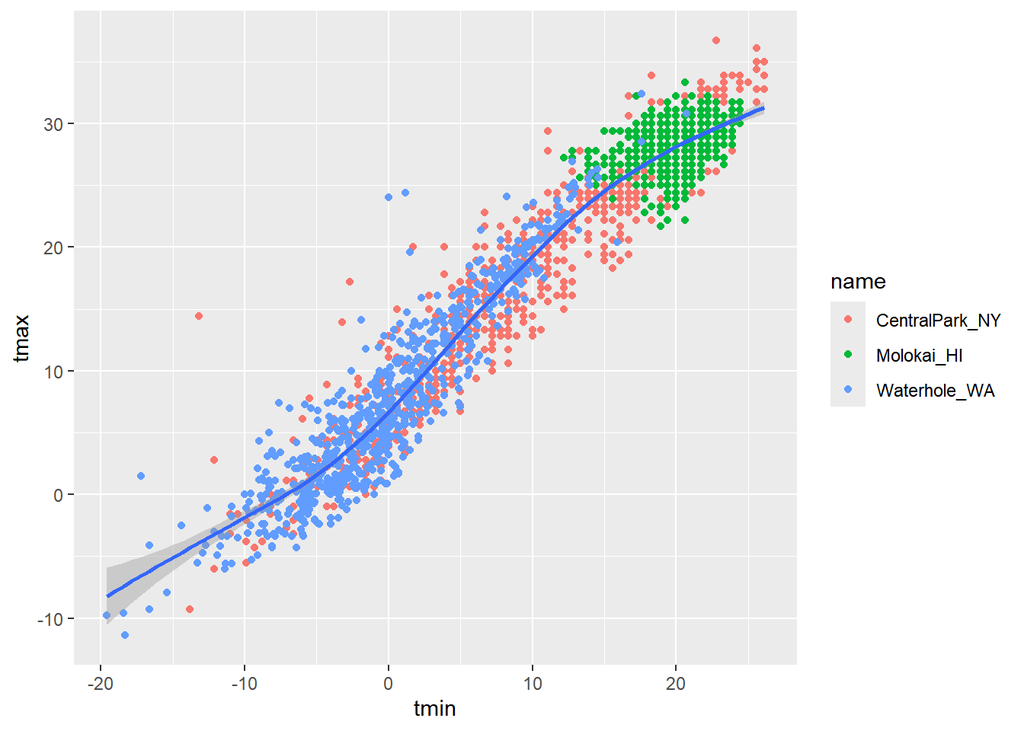

```r
weather_df %>%
  ggplot(aes(x=tmin, y=tmax)) +
  geom_point(aes(color=name)) +
  geom_smooth()
```

（aes 在 geom_point() 中局部映射，color=name 只作用于点图层，只有散点按 name 分组着色，所有数据点一起拟合，只生成一条总的拟合线）

Let’s facet some things!

(facet_grid(行变量~列变量)，如果没有变量用‘.’代替)

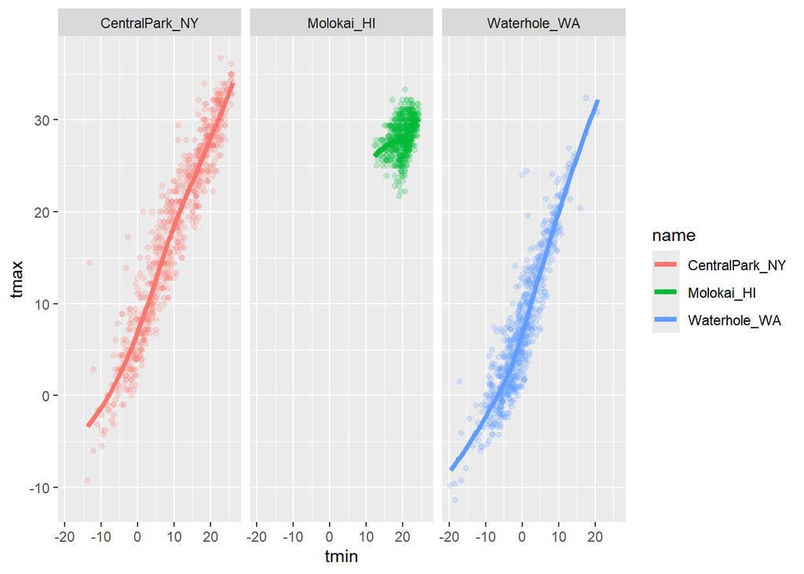

```r
weather_df %>%
  ggplot(aes(x=tmin, y=tmax, color=name)) +
  geom_point(alpha=.2)+
  geom_smooth(se=FALSE, size=1.5) +
  facet_grid(.~ name)
```

(alpha 参数控制透明度, 取值范围：0（完全透明）到 1（完全不透明）)

Or write like this:

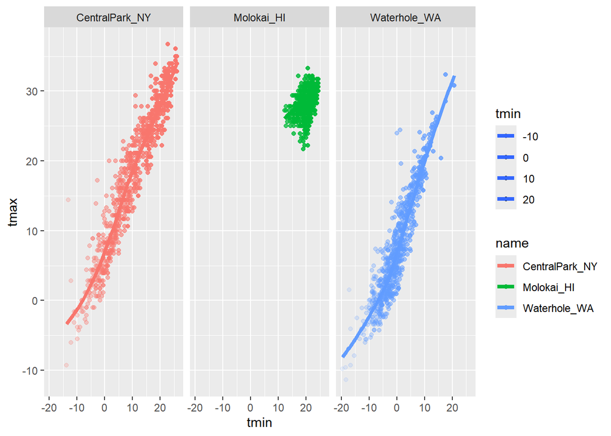

```r
weather_df %>%
  ggplot(aes(x=tmin, y=tmax, alpha=tmin, color=name)) +
  geom_point()+
  geom_smooth(se=FALSE, size=1.5) +
  facet_grid(.~ name)
```

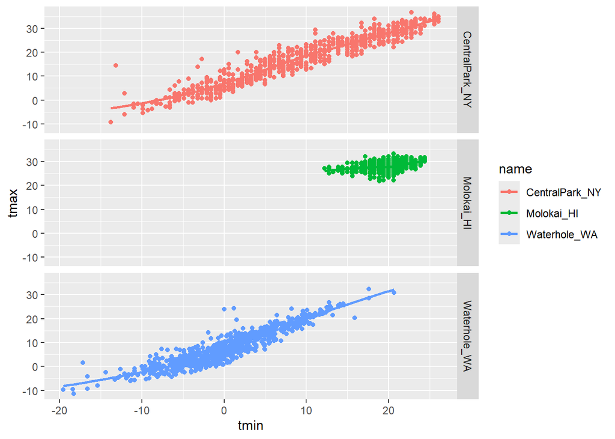

```r
weather_df %>%
  ggplot(aes(x=tmin, y=tmax, color=name)) +
  geom_point()+
  geom_smooth(se=FALSE) +
  facet_grid(name~.)
```

Let’s combine some elements and try a new plot.

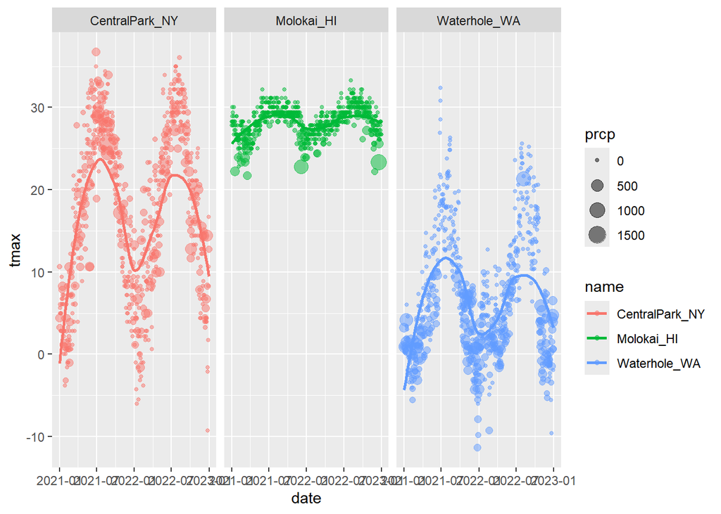

```r
weather_df %>%
  ggplot(aes(x=date, y=tmax, color=name)) +
  geom_point(aes(size = prcp),alpha=.5)+
  geom_smooth(se=FALSE)+
  facet_grid(.~ name)
```

## Some small notes

How many geoms have to exist? You can have whatever geoms you want.

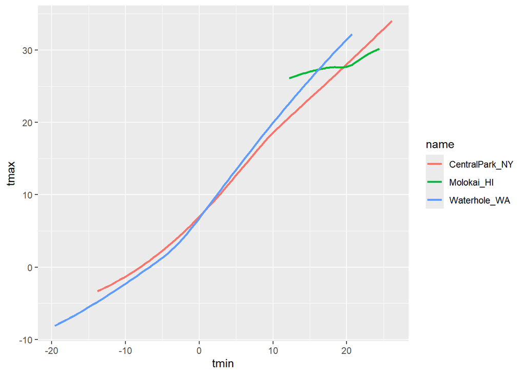

```r
weather_df %>%
  ggplot(aes(x=tmin, y=tmax, color=name))+
  geom_smooth(se=FALSE)
```

You can use a neat geom!

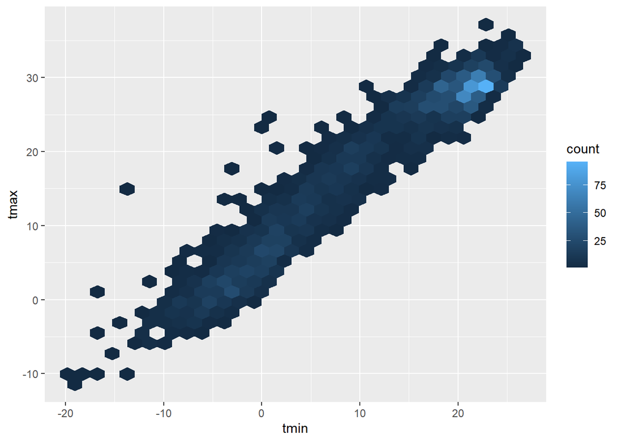

```r
weather_df %>%
  ggplot(aes(x=tmin, y=tmax))+
  geom_hex()
```

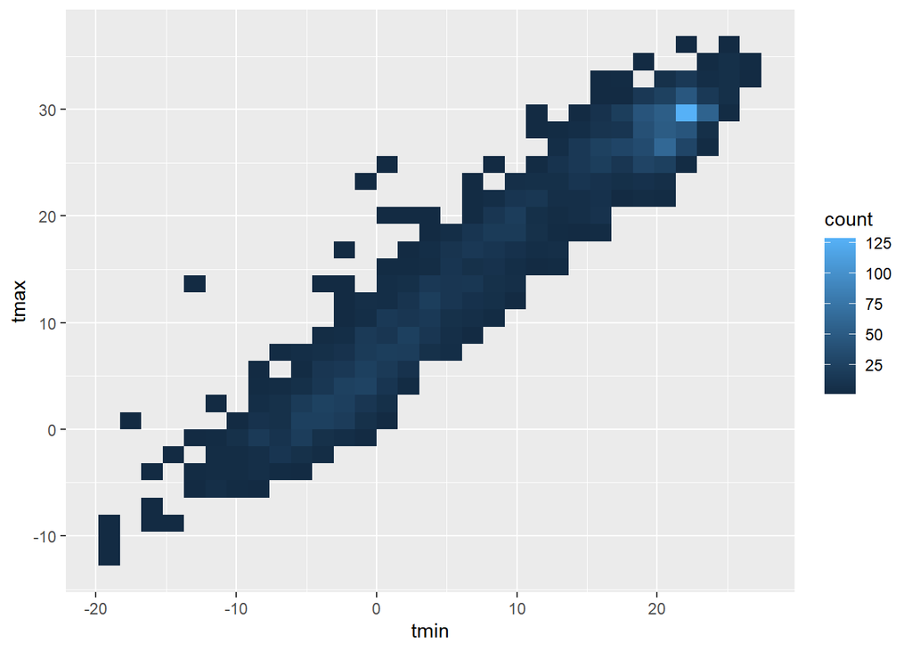

```r
weather_df %>%
  ggplot(aes(x=tmin, y=tmax))+
  geom_bin_2d()
```

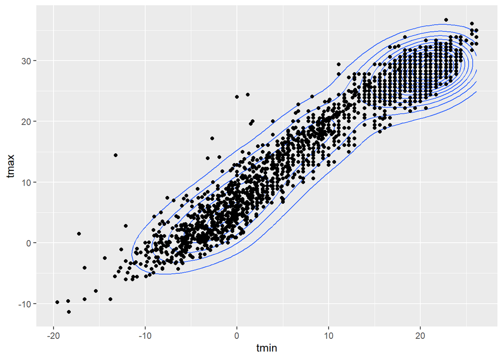

```r
weather_df %>%
  ggplot(aes(x=tmin, y=tmax))+
  geom_density_2d()+
  geom_point()
```

# Univariate plots

### Histograms are really great.

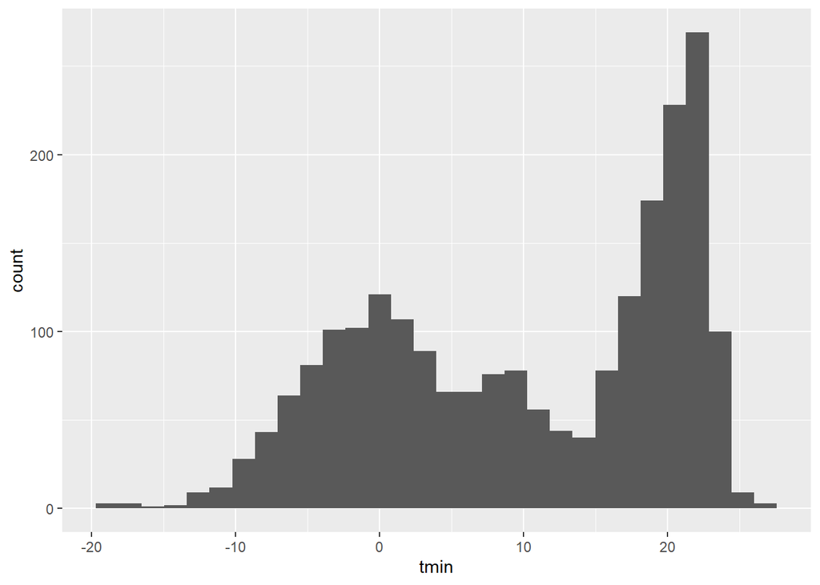

```r
weather_df %>%
  ggplot(aes(x=tmin))+
  geom_histogram()
```

Can we add color..

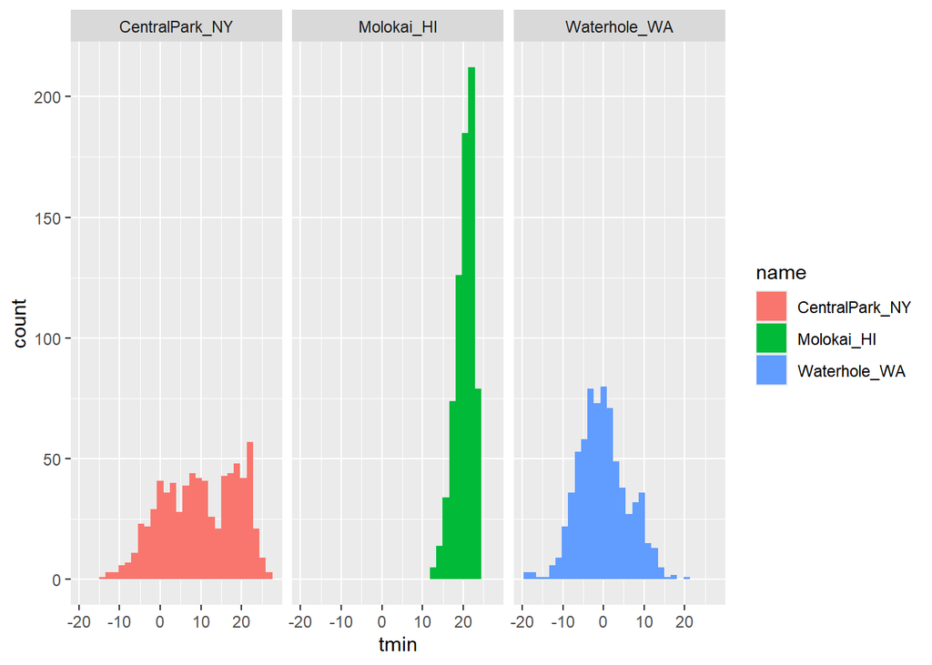

```r
weather_df %>%
  ggplot(aes(x=tmin, fill=name))+
  geom_histogram(position = "dodge")+
  facet_grid(.~name)
```

(position = “dodge”：让不同组别的条形并排显示，而不是堆叠在一起) (position = “stack”：（堆叠，默认值）) (position = “fill”（比例堆叠）)

Let’s try a new geometry!

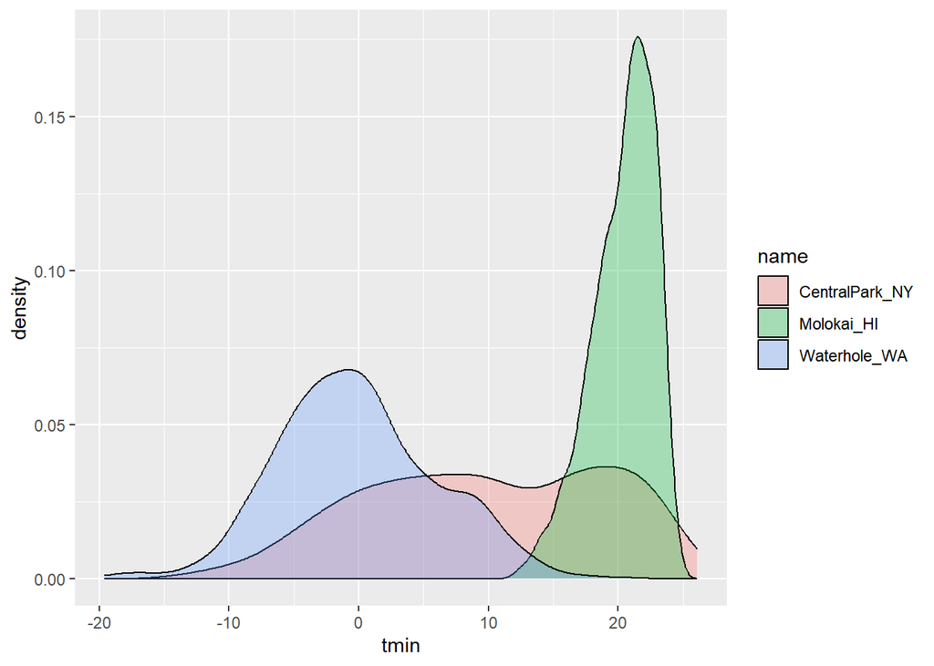

```r
weather_df %>%
  ggplot(aes(x=tmin, fill=name))+
  geom_density(alpha=.3)
```

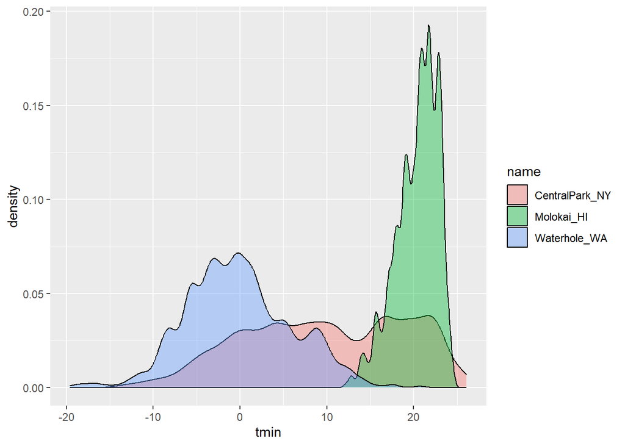

```r
weather_df %>%
  ggplot(aes(x=tmin, fill=name))+
  geom_density(alpha=.4, adjust=.5)
```

(adjust 参数：调整密度估计的带宽（bandwidth） adjust = 1：使用默认带宽（标准平滑度） adjust < 1：减小带宽 → 曲线更崎岖、更多细节 adjust > 1：增大带宽 → 曲线更平滑、更概化)

### What about box plot?

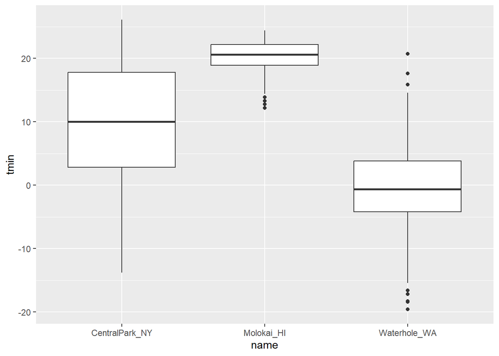

```r
weather_df %>%
  ggplot(aes(x=name, y=tmin))+
  geom_boxplot()
```

### Trendy plots :-)

```
## No summary function supplied, defaulting to `mean_se()`
```

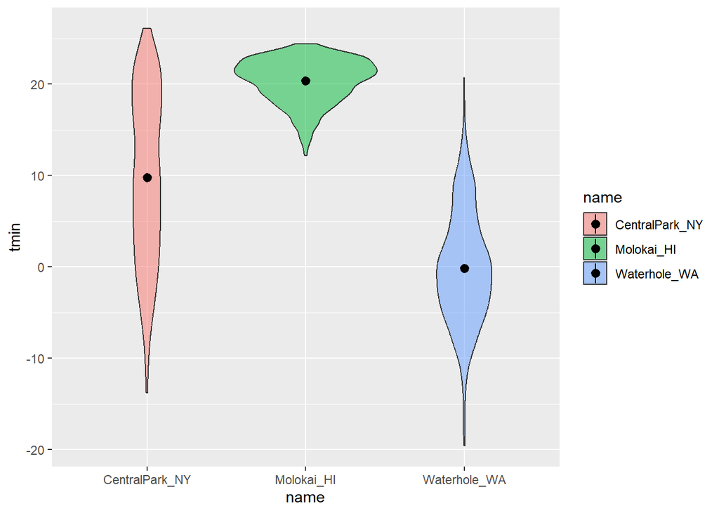

```r
weather_df %>%
  ggplot(aes(x=name, y=tmin, fill=name)) +
  geom_violin(alpha=.5)+
stat_summary()
```

(stat_summary():统计汇总函数，在数据上自动计算并显示摘要统计量,默认计算每个 x 分组的 y 值的均值并用点表示)

### Ridge plots — most popular plot of 2017

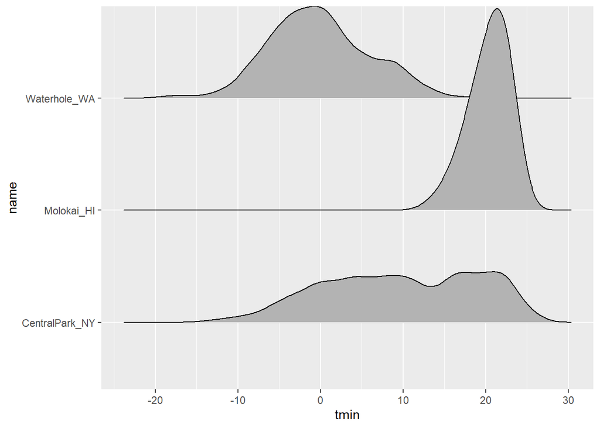

```r
weather_df %>%
  ggplot(aes(x=tmin, y=name))+
  geom_density_ridges()
```

# Save and Embed

### Let’s save a scatterplot.

```r
weather_plot=
  weather_df %>%
  ggplot(aes(x=tmin, y=tmax, color=name))+
  geom_point(alpha=.5)

ggsave("./results/weather_plot.pdf", weather_plot, width = 8, height = 5)
```

### What about embedding…

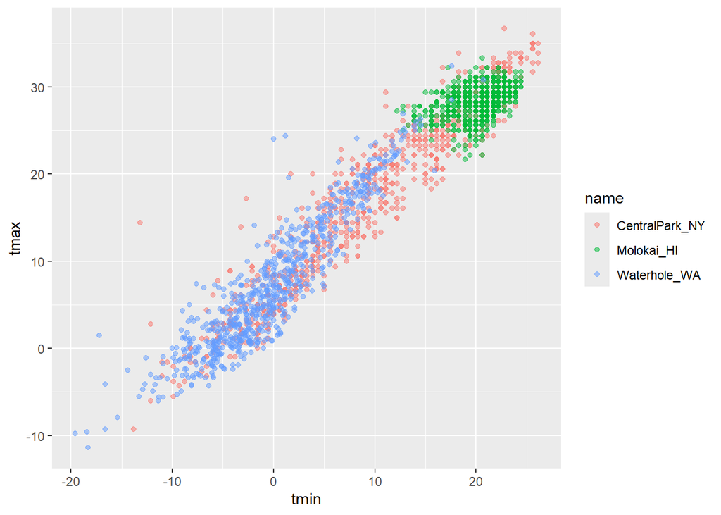

```r
weather_plot
```

Embed at different size:

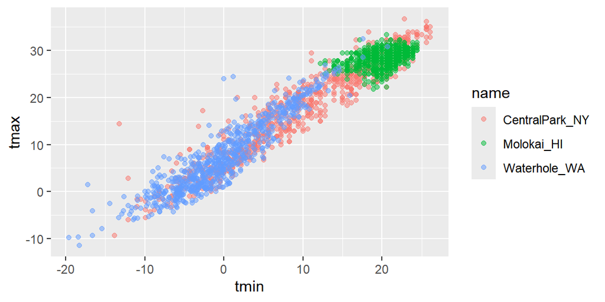

```r
weather_plot
```